# Report

Tuva Norderud Jensen, Eirik Røys, Kathrine Brun

2024-09-13

## Original data

The original data came from the [medicaldata webpage](https://higgi13425.github.io/medicaldata/reference/licorice_gargle.html) and transformed into a not tidy format before it was given to us to use as part of the RMED901 exam in fall 2024.

The data is taken from a study of patients undergoing elective thoracic surgery requiring a double-lumen endotracheal tube. 236 adult patients were enrolled. The study investigates whether gargling with licorice before anesthesia can prevent postoperative sore throat and coughing in these patients. Data on Gender, physical status, BMI, age, Mallampati score, smoking status, preoperative pain, surgery size, intervention and the outcomes (cough, sore throat and pain swallowing at various time points) are provided in the original data. For more information on the data see codebook.

## Reading data

```r
data
```

```
## # A tibble: 265 × 20
##    patient_id month  year preOp_gender `BMI kg/m2` preOp_age preOp_smoking
##         <dbl> <dbl> <dbl>        <dbl>       <dbl>     <dbl>         <dbl>
##  1          1    10  2009            0        33.0        67             1
##  2          2     3  2008            0        23.7        76             2
##  3          3     3  2009            0        26.8        58             1
##  4          4     3  2008            0        28.4        59             1
##  5          5     4  2010            0        30.4        73             2
##  6          6    12  2008            0        35.5        61             1
##  7          7    10  2008            0        25.5        66             1
##  8          8     3  2008            0        31.1        61             1
##  9          9     8  2010            0        21.2        83             1
## 10         10    11  2008            0        27.2        69             3
## # ℹ 255 more rows
## # ℹ 13 more variables: preOp_pain <dbl>, treat <dbl>, pacu30min_cough <dbl>,
## #   pacu30min_throatPain <dbl>, pacu30min_swallowPain <dbl>,
## #   pacu90min_cough <dbl>, pacu90min_throatPain <dbl>, postOp4hour_cough <dbl>,
## #   postOp4hour_throatPain <dbl>, pod1am_cough <dbl>, pod1am_throatPain <dbl>,
## #   `1gender` <dbl>, preOp_ASA_Mallampati <chr>
```

```r
joindata
```

```
## # A tibble: 245 × 3
##    patient_id intraOp_surgerySize extubation_cough
##         <dbl>               <dbl>            <dbl>
##  1          1                   2                0
##  2          2                   1                0
##  3          3                   2                0
##  4          4                   3                0
##  5          5                   2                0
##  6          6                   3                0
##  7          7                   3                0
##  8          8                   1                0
##  9          9                   1                0
## 10         10                   2                0
## # ℹ 235 more rows
```

### Joining datasets

```r
combined_data <- data %>%
  full_join(joindata, join_by("patient_id"), relationship = "many-to-many")

combined_data
```

```
## # A tibble: 277 × 22
##    patient_id month  year preOp_gender `BMI kg/m2` preOp_age preOp_smoking
##         <dbl> <dbl> <dbl>        <dbl>       <dbl>     <dbl>         <dbl>
##  1          1    10  2009            0        33.0        67             1
##  2          2     3  2008            0        23.7        76             2
##  3          3     3  2009            0        26.8        58             1
##  4          4     3  2008            0        28.4        59             1
##  5          5     4  2010            0        30.4        73             2
##  6          6    12  2008            0        35.5        61             1
##  7          7    10  2008            0        25.5        66             1
##  8          8     3  2008            0        31.1        61             1
##  9          9     8  2010            0        21.2        83             1
## 10         10    11  2008            0        27.2        69             3
## # ℹ 267 more rows
## # ℹ 15 more variables: preOp_pain <dbl>, treat <dbl>, pacu30min_cough <dbl>,
## #   pacu30min_throatPain <dbl>, pacu30min_swallowPain <dbl>,
## #   pacu90min_cough <dbl>, pacu90min_throatPain <dbl>, postOp4hour_cough <dbl>,
## #   postOp4hour_throatPain <dbl>, pod1am_cough <dbl>, pod1am_throatPain <dbl>,
## #   `1gender` <dbl>, preOp_ASA_Mallampati <chr>, intraOp_surgerySize <dbl>,
## #   extubation_cough <dbl>
```

## Making Tidy Data

To tidy the data we had to:

- Identify rows with any NA values
  - We excluded the two patients that had NA values since they were missing all postOp values.
- Change variable types
- Rearrange the dataset
  - Rename columns
  - Combine month and year into one column
  - Split preOp_ASA_Mallampati into two columns
  - Add postop_cough_change_extubation, postop_throatpain_change and BMI_quartile column
  - Change column coding gender to “Male” and “Female” instead of “0”/“1”
- Remove duplicated columns and rows
- Rearranged the dataset

### Dealing with missing values

```r
na_rows <- combined_data %>%
  filter(if_any(everything(), is.na))

print(na_rows)
```

```
## # A tibble: 2 × 22
##   patient_id month  year preOp_gender `BMI kg/m2` preOp_age preOp_smoking
##        <dbl> <dbl> <dbl>        <dbl>       <dbl>     <dbl>         <dbl>
## 1        113     3  2009            0        24.6        70             2
## 2        123     1  2008            0        30.3        69             2
## # ℹ 15 more variables: preOp_pain <dbl>, treat <dbl>, pacu30min_cough <dbl>,
## #   pacu30min_throatPain <dbl>, pacu30min_swallowPain <dbl>,
## #   pacu90min_cough <dbl>, pacu90min_throatPain <dbl>, postOp4hour_cough <dbl>,
## #   postOp4hour_throatPain <dbl>, pod1am_cough <dbl>, pod1am_throatPain <dbl>,
## #   `1gender` <dbl>, preOp_ASA_Mallampati <chr>, intraOp_surgerySize <dbl>,
## #   extubation_cough <dbl>
```

```r
combined_data <- combined_data %>%
  drop_na()
```

### Changing variable types

```
## tibble [275 × 22] (S3: tbl_df/tbl/data.frame)
##  $ patient_id            : num [1:275] 1 2 3 4 5 6 7 8 9 10 ...
##  $ month                 : num [1:275] 10 3 3 3 4 12 10 3 8 11 ...
##  $ year                  : num [1:275] 2009 2008 2009 2008 2010 ...
##  $ preOp_gender          : num [1:275] 0 0 0 0 0 0 0 0 0 0 ...
##  $ BMI kg/m2             : num [1:275] 33 23.7 26.8 28.4 30.4 ...
##  $ preOp_age             : num [1:275] 67 76 58 59 73 61 66 61 83 69 ...
##  $ preOp_smoking         : Factor w/ 3 levels "1","2","3": 1 2 1 1 2 1 1 1 1 3 ...
##  $ preOp_pain            : Factor w/ 2 levels "0","1": 1 1 1 1 1 1 1 1 1 1 ...
##  $ treat                 : Factor w/ 2 levels "0","1": 2 2 2 2 2 2 2 2 2 2 ...
##  $ pacu30min_cough       : Factor w/ 3 levels "0","1","2": 1 1 1 1 1 1 1 1 1 1 ...
##  $ pacu30min_throatPain  : num [1:275] 0 0 0 0 0 0 0 0 0 0 ...
##  $ pacu30min_swallowPain : num [1:275] 0 0 0 0 0 0 0 0 0 0 ...
##  $ pacu90min_cough       : Factor w/ 3 levels "0","1","2": 1 1 1 1 1 1 1 1 1 1 ...
##  $ pacu90min_throatPain  : num [1:275] 0 0 0 0 0 0 0 0 0 0 ...
##  $ postOp4hour_cough     : Factor w/ 3 levels "0","1","2": 1 1 1 1 1 1 1 1 1 1 ...
##  $ postOp4hour_throatPain: num [1:275] 0 0 0 0 0 0 0 0 0 0 ...
##  $ pod1am_cough          : Factor w/ 4 levels "0","1","2","3": 1 1 1 1 1 1 1 1 1 1 ...
##  $ pod1am_throatPain     : num [1:275] 0 0 0 0 0 0 0 0 0 0 ...
##  $ 1gender               : num [1:275] 0 0 0 0 0 0 0 0 0 0 ...
##  $ preOp_ASA_Mallampati  : Factor w/ 10 levels "1_1","1_2","1_3",..: 8 5 5 5 1 6 7 5 7 8 ...
##  $ intraOp_surgerySize   : num [1:275] 2 1 2 3 2 3 3 1 1 2 ...
##  $ extubation_cough      : Factor w/ 3 levels "0","1","2": 1 1 1 1 1 1 1 1 1 1 ...
```

### Rearranging dataset

- renaming columns
- combined month and year into a single column “date in month-year (my) format
- split the coloumn ASA_Mallampati into two separate variables
- sorted rows based in patient ID
- added new columns showing change in cough and throat pain
- cutting BMI into quartiles
- Reordering columns and selecting which to keep

```
## # A tibble: 275 × 25
##    patient_id   BMI   age smoking gender date       preOp_gender preOp_pain
##         <dbl> <dbl> <dbl> <fct>   <fct>  <date>            <dbl> <fct>
##  1          1  33.0    67 1       Male   2009-10-01            0 0
##  2          1  33.0    67 1       Male   2009-06-01            0 0
##  3          2  23.7    76 2       Male   2008-03-01            0 0
##  4          2  23.7    76 2       Male   2009-11-01            0 0
##  5          3  26.8    58 1       Male   2009-03-01            0 0
##  6          4  28.4    59 1       Male   2008-03-01            0 0
##  7          5  30.4    73 2       Male   2010-04-01            0 0
##  8          5  30.4    73 2       Male   2010-02-01            0 0
##  9          6  35.5    61 1       Male   2008-12-01            0 0
## 10          7  25.5    66 1       Male   2008-10-01            0 0
## # ℹ 265 more rows
## # ℹ 17 more variables: treat <fct>, pacu30min_cough <fct>,
## #   pacu30min_throatPain <dbl>, pacu30min_swallowPain <dbl>,
## #   pacu90min_cough <fct>, pacu90min_throatPain <dbl>, postOp4hour_cough <fct>,
## #   postOp4hour_throatPain <dbl>, pod1am_cough <fct>, pod1am_throatPain <dbl>,
## #   ASA_score <chr>, Mallampati_score <chr>, intraOp_surgerySize <dbl>,
## #   extubation_cough <fct>, postop_cough_change_extubation <dbl>, …
```

### Removing duplicates

```r
unique(combined_data$preOp_gender == combined_data$gender)
```

```
## [1] FALSE
```

```r
combined_data$preOp_gender <- NULL
```

```r
combined_data <- combined_data %>%
  group_by_all() %>%
  filter(n() == 1) %>%
  ungroup()

combined_data <- combined_data %>%
  distinct(.keep_all = TRUE)

combined_data %>%
  filter(patient_id==48)
```

```
## # A tibble: 0 × 24
## # ℹ 24 variables: patient_id <dbl>, BMI <dbl>, age <dbl>, smoking <fct>,
## #   gender <fct>, date <date>, preOp_pain <fct>, treat <fct>,
## #   pacu30min_cough <fct>, pacu30min_throatPain <dbl>,
## #   pacu30min_swallowPain <dbl>, pacu90min_cough <fct>,
## #   pacu90min_throatPain <dbl>, postOp4hour_cough <fct>,
## #   postOp4hour_throatPain <dbl>, pod1am_cough <fct>, pod1am_throatPain <dbl>,
## #   ASA_score <chr>, Mallampati_score <chr>, intraOp_surgerySize <dbl>, …
```

## Stratifying data

### Data was stratified by a gender and min, max, mean and sd of age was reported.

```r
combined_data %>%
  filter(gender == "Female") %>%
  summarise(min(age), max(age), mean(age), sd(age))
```

```
## # A tibble: 1 × 4
##   `min(age)` `max(age)` `mean(age)` `sd(age)`
##        <dbl>      <dbl>       <dbl>     <dbl>
## 1         23         86        57.2      14.1
```

### Data stratified by the following instructions:

- BMI <25
- Gender = female
- Age > 50
- extubation_cough = TRUE

```r
combined_data %>%
  filter(BMI < 25 ) %>%
  filter(gender == "Female") %>%
  filter(age > 50) %>%
  filter(extubation_cough = TRUE) %>%
  summarise(min(age), max(age), mean(age), sd(age))
```

```
## # A tibble: 1 × 4
##   `min(age)` `max(age)` `mean(age)` `sd(age)`
##        <dbl>      <dbl>       <dbl>     <dbl>
## 1         53         86        67.8      9.22
```

### Table based on gender and BMI_quartile

```r
combined_data %>%
  count(gender, BMI_quartile) %>%
  arrange(gender, BMI_quartile)
```

```
## # A tibble: 8 × 3
##   gender BMI_quartile     n
##   <fct>  <fct>        <int>
## 1 Male   Q1              27
## 2 Male   Q2              38
## 3 Male   Q3              43
## 4 Male   Q4              45
## 5 Female Q1              30
## 6 Female Q2              25
## 7 Female Q3              22
## 8 Female Q4              19
```

## Plots

```r
data <- read.csv2(here("DATA", "clean_data.csv"))
```

### **Analyis: Relationship between variables**

#### **Are there any correlated measurements?**

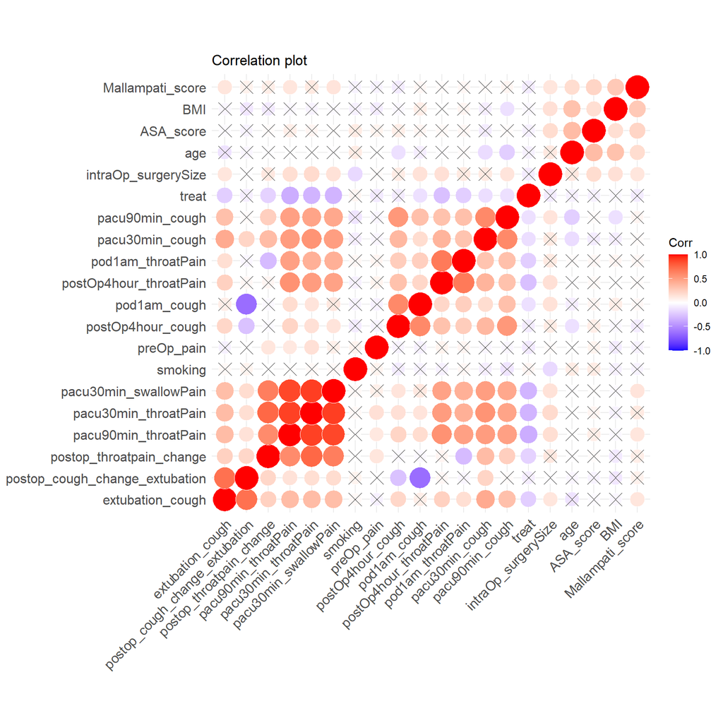

```r
# Create correlation matrix excluding non-numeric and irrelevant columns
corr <- data %>%
  select(-gender, -date, -BMI_quartile, -patient_id) %>%
  cor()

# Create matrix of correlation p-values
p.mat <- data %>%
  select(-gender, -date, -BMI_quartile, -patient_id) %>%
  cor_pmat()

# Plot the correlation matrix with p-values
corr_plot <- ggcorrplot(corr,
                        method = "circle",
                        hc.order = TRUE,
                        title = "Correlation plot",
                        outline.color = "white",
                        p.mat = p.mat
)

# Display plot
corr_plot
```

**Conclusion: several measurements are correlated: e.g., `pacu30min_swallowPain` and `pacu30min_throatpain`**

### **Does the `age` distribution depend on `treat`?**

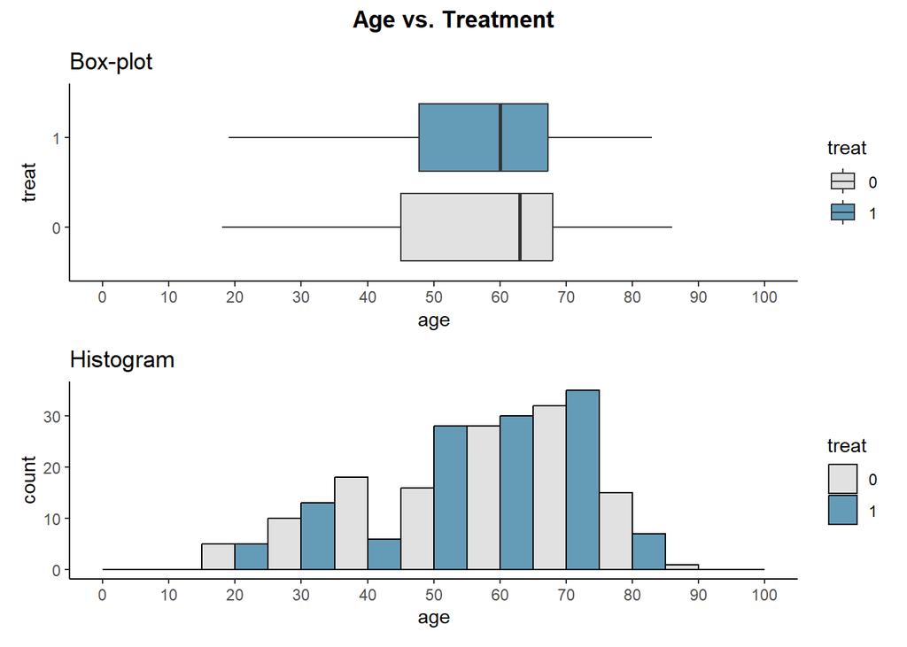

```r
# Boxplot Age vs. Treat
boxplot_treat <- ggplot(data, aes(x = treat, y = age, fill = treat)) +
  geom_boxplot() +
  scale_fill_manual(values = c("0" = "#E1E1E1", "1" = "#649CB8")) +
  scale_y_continuous(breaks = c(0, 10, 20, 30, 40, 50, 60, 70, 80, 90, 100), limits = c(0, 100)) +
  labs(title = "Box-plot") +
  theme_classic() +
  coord_flip()

# Histogram Age vs. Treat
histogram_treat <- ggplot(data, aes(y = age, fill = treat)) +
  geom_histogram(binwidth = 10, position = "dodge", color = "black") +
  scale_fill_manual(values = c("0" = "#E1E1E1", "1" = "#649CB8")) +
  scale_y_continuous(breaks = c(0, 10, 20, 30, 40, 50, 60, 70, 80, 90, 100), limits = c(0, 100)) +
  labs(title = "Histogram") +
  theme_classic() +
  coord_flip()

# Combine plots
Age_vs_treat_plot <- (boxplot_treat / histogram_treat) +
  plot_annotation(
    title = "Age vs. Treatment",
    theme = theme(plot.title = element_text(hjust = 0.5, face = "bold"))
  )

# Display the plot
Age_vs_treat_plot
```

**Conclusion: the distribution of `age` does not appear to depend on `treatment`.**

### **Does the `age` distribution of the patients depend on their `gender`?**

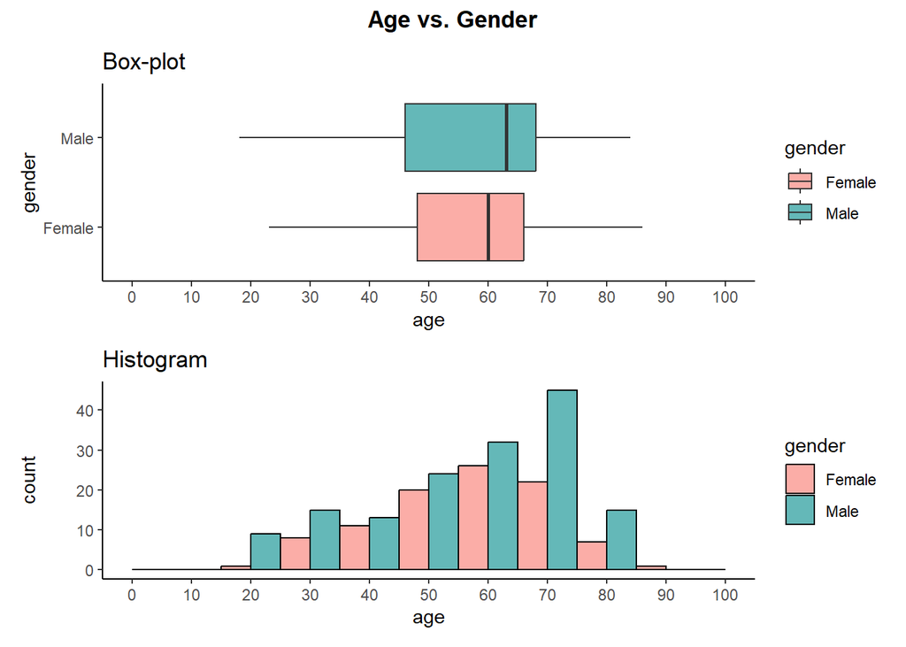

```r
# Boxplot: Age vs. Gender
boxplot_gender <- ggplot(data, aes(x = gender, y = age, fill = gender)) +
  geom_boxplot() +
  scale_fill_manual(values = c("Female" = "#FBADA7", "Male" = "#64B8B8")) +
  scale_y_continuous(breaks = c(0, 10, 20, 30, 40, 50, 60, 70, 80, 90, 100), limits = c(0, 100)) +
  labs(title = "Box-plot") +
  theme_classic() +
  coord_flip()

# Histogram: Age vs. Gender
histogram_gender <- ggplot(data, aes(y = age, fill = gender)) +
  geom_histogram(binwidth = 10, position = "dodge", color = "black") +
  scale_fill_manual(values = c("Female" = "#FBADA7", "Male" = "#64B8B8")) +
  scale_y_continuous(breaks = c(0, 10, 20, 30, 40, 50, 60, 70, 80, 90, 100), limits = c(0, 100)) +
  labs(title = "Histogram") +
  theme_classic() +
  coord_flip()

# Combine plots
Age_vs_gender_plot <- (boxplot_gender / histogram_gender) +
  plot_annotation(
    title = "Age vs. Gender",
    theme = theme(plot.title = element_text(hjust = 0.5, face = "bold"))
  )

# Display the plot
Age_vs_gender_plot
```

**Conclusion: The distribution of `age` does not appear to depend on `gender`.**

### **Do `BMI` and `age` have a linear relationship?**

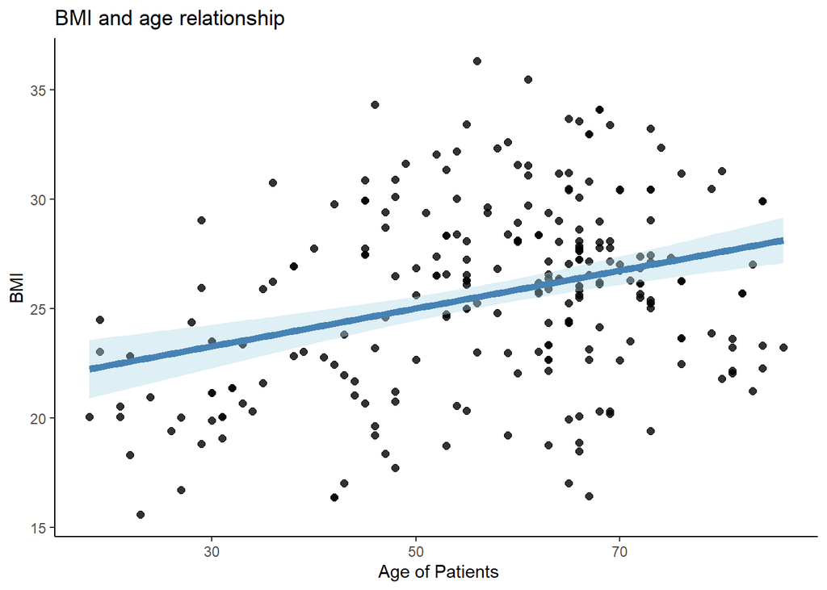

```r
# ---- Do BMI and age have a linear relationship? -----------------------------------------

Regresssion_plot <- ggplot(data, aes(x = age, y = as.numeric(BMI))) +
  geom_point(alpha = 0.8, size = 2) +
  geom_smooth(method = "lm", color = "steelblue", se = TRUE, size = 2, fill = "lightblue") +
  labs(
    title = "BMI and age relationship",
    x = " Age of Patients",
    y = "BMI"
  ) +
  theme_classic()

# Display the plot
Regresssion_plot
```

**Conclusion: it appears to be a linear relationship between `BMI` and `age`.**

### **Does the `preOp_pain` change with the `age` of the patients?**

```r
sum(data$preOp_pain == 1)
```

```
## [1] 2
```

```r
sum(data$preOp_pain != 1)
```

```
## [1] 247
```

**Conclusion: Only two patients (out of 249) reported `preOp_pain` - there is insufficient data to test for a relationship.**

## Statistical analysis

### Does the treatment depend on the preoperative smoking?

```r
logistic_model <- glm(data$treat ~ data$smoking, family = binomial())
summary(logistic_model)
```

```
##
## Call:
## glm(formula = data$treat ~ data$smoking, family = binomial())
##
## Coefficients:
##               Estimate Std. Error z value Pr(>|z|)
## (Intercept)   -0.05942    0.19910  -0.298    0.765
## data$smoking2 -0.10763    0.30916  -0.348    0.728
## data$smoking3  0.27073    0.30473   0.888    0.374
##
## (Dispersion parameter for binomial family taken to be 1)
##
##     Null deviance: 345.18  on 248  degrees of freedom
## Residual deviance: 343.75  on 246  degrees of freedom
## AIC: 349.75
##
## Number of Fisher Scoring iterations: 3
```

**The likelihood of receiving licorice treatment do not depend on Preoperative smoking status (P > 0.05).**

### Does the treatment depend on the gender of the patient?

```r
logistic_model_treatment_gender <- glm(data$treat ~ data$gender, family = binomial())
summary(logistic_model_treatment_gender)
```

```
##
## Call:
## glm(formula = data$treat ~ data$gender, family = binomial())
##
## Coefficients:
##                 Estimate Std. Error z value Pr(>|z|)
## (Intercept)      0.08338    0.20430   0.408    0.683
## data$genderMale -0.14876    0.26060  -0.571    0.568
##
## (Dispersion parameter for binomial family taken to be 1)
##
##     Null deviance: 345.18  on 248  degrees of freedom
## Residual deviance: 344.86  on 247  degrees of freedom
## AIC: 348.86
##
## Number of Fisher Scoring iterations: 3
```

**The likelihood of receiving licorice treatment does not depend on gender (P > 0.05).**

### Does the treatment depend on whether the patient had a preoperative pain?

```r
logistic_model_treatment_preoppain <- glm(data$treat ~ data$preOp_pain, family = binomial())
summary(logistic_model_treatment_preoppain)
```

```
##
## Call:
## glm(formula = data$treat ~ data$preOp_pain, family = binomial())
##
## Coefficients:
##                    Estimate Std. Error z value Pr(>|z|)
## (Intercept)        0.008097   0.127258   0.064    0.949
## data$preOp_pain1 -14.574165 624.193840  -0.023    0.981
##
## (Dispersion parameter for binomial family taken to be 1)
##
##     Null deviance: 345.18  on 248  degrees of freedom
## Residual deviance: 342.41  on 247  degrees of freedom
## AIC: 346.41
##
## Number of Fisher Scoring iterations: 13
```

**The likelihood of receiving licorice treatment does not depend on preoperative pain (P > 0.05).**

### Was the treatment with licorice gargle reducing the risk of post operative throat pain?

#### We performed a logistic regression between “treat” and “throat pain” reported at four time intervals after surgery (30min, 90min,4hours and 1am)

```r
model_pacu30min_throatPain <- glm(pacu30min_throatPain ~ treat, data = data, family = binomial)
summary(model_pacu30min_throatPain)
odds_ratio_pacu30min <- (exp(coef(model_pacu30min_throatPain)["treat1"]) - 1) * 100
odds_ratio_pacu30min
```

[output not shown]

**P<0.05, odds ratio shows 65.4% risk reduction of having throat pain when treated with licorice gargling before intubation**

```r
model_pacu90min_throatPain <- glm(pacu90min_throatPain ~ treat, data = data, family = binomial)
summary(model_pacu90min_throatPain)
odds_ratio_pacu90min <- (exp(coef(model_pacu90min_throatPain)["treat1"]) - 1) * 100
odds_ratio_pacu90min
```

[output not shown]

**P<0.05, odds ratio shows 80.6% risk reduction of having throat pain when treated with licorice gargling before intubation**

```r
model_postOp4hour_throatPain <- glm(postOp4hour_throatPain ~ treat, data = data, family = binomial)
summary(model_postOp4hour_throatPain)
odds_ratio_postOp4hours <- (exp(coef(model_postOp4hour_throatPain)["treat1"]) - 1) * 100
odds_ratio_postOp4hours
```

[output not shown]

**P<0.05, odds ratio shows 70.3% risk reduction of having throat pain when treated with licorice gargling before intubation**

```r
model_pod1am_throatPain <- glm(pod1am_throatPain ~ treat, data = data, family = binomial)
summary(model_pod1am_throatPain)
odds_ratio_pod1am <- (exp(coef(model_pod1am_throatPain)["treat1"]) - 1) * 100
odds_ratio_pod1am
```

[output not shown]

**P<0.05, odds ratio shows 66.8% risk reduction of having throat pain when treated with licorice gargling before intubation**

## Codebook

For the updated codebook see here